# Lab Assignment Three: Extending Logistic Regression

Eric Houtman, Rick Lattin, Kellen Long

## Business Understanding

#### Machine Learning in Astronomy

Astronomy generates lots of data. Machine learning algorithms can make processing and analyzing said datasets quicker and more efficient, allowing for discoveries to be made more quickly. Similarly, machine learning algorithms excel at identifying patterns in complex data. Using our work shown below, this will aid in more quickly classifying new stars, galaxies, and quasars. This will take much of the burden off of scientist's shoulders, allowing them to more efficiently use their time and resources charting and discovering our universe.

The Stellar Classification Dataset used below has 100,000 observations from the Sloan Digital Sky Survey (SDSS). It has 17 features including an ultraviolet, green, red, near infared, and infared band filter, alpha and delta of the telescope, the redshift of the body, and a few others used for part identification that we plan to ignore. The target variable is the type of celestial body, which can be a galaxy, star, or quasar.

In order for this machine learning algorithm to be considered useful, we believe that our classifier should have a precision of at least 85%, that way a vast majority of celestial bodies would be correctly classified.

We also plan to split our data into an 80% training and 20% testing set. We believe that this will provide enough data to accurately train our model, while also providing enough data to test our model's accuracy and measure a valid precision score.

===============================================================================================================

Datasets: Stellar Classification Dataset - SDSS17 URL: https://www.kaggle.com/datasets/fedesoriano/stellar-classification-dataset-sdss17

References:https://github.com/eclarson/MachineLearningNotebooks/blob/master/05.%20Logistic%20Regression.ipynb

Github: https://github.com/eclarson/MachineLearningNotebooks/blob/master/06.%20Optimization.ipynb

```python
#clear all tables
%reset -f

import pandas as pd
import numpy as np
import matplotlib.pyplot as plt
import seaborn as sns

import warnings
warnings.filterwarnings('ignore')

# Read the data
dataTrain = pd.read_csv('star_classification.csv')

#Capitalize the column names
dataTrain.columns = dataTrain.columns.str.upper()

dataTrain.head()
```

|  | OBJ_ID | ALPHA | DELTA | U | G | R | I | Z | RUN_ID | RERUN_ID | CAM_COL | FIELD_ID | SPEC_OBJ_ID | CLASS | REDSHIFT | PLATE | MJD | FIBER_ID |
| --- | --- | --- | --- | --- | --- | --- | --- | --- | --- | --- | --- | --- | --- | --- | --- | --- | --- | --- |
| 0 | 1.237661e+18 | 135.689107 | 32.494632 | 23.87882 | 22.27530 | 20.39501 | 19.16573 | 18.79371 | 3606 | 301 | 2 | 79 | 6.543777e+18 | GALAXY | 0.634794 | 5812 | 56354 | 171 |
| 1 | 1.237665e+18 | 144.826101 | 31.274185 | 24.77759 | 22.83188 | 22.58444 | 21.16812 | 21.61427 | 4518 | 301 | 5 | 119 | 1.176014e+19 | GALAXY | 0.779136 | 10445 | 58158 | 427 |
| 2 | 1.237661e+18 | 142.188790 | 35.582444 | 25.26307 | 22.66389 | 20.60976 | 19.34857 | 18.94827 | 3606 | 301 | 2 | 120 | 5.152200e+18 | GALAXY | 0.644195 | 4576 | 55592 | 299 |
| 3 | 1.237663e+18 | 338.741038 | -0.402828 | 22.13682 | 23.77656 | 21.61162 | 20.50454 | 19.25010 | 4192 | 301 | 3 | 214 | 1.030107e+19 | GALAXY | 0.932346 | 9149 | 58039 | 775 |
| 4 | 1.237680e+18 | 345.282593 | 21.183866 | 19.43718 | 17.58028 | 16.49747 | 15.97711 | 15.54461 | 8102 | 301 | 3 | 137 | 6.891865e+18 | GALAXY | 0.116123 | 6121 | 56187 | 842 |

After reading in the data, we take out one very extreme outlier, then drop a few columns that we believe will not be helpful to our classification. We then set all of the labels to 0, 1, or 2 to assist with classification.

```python
# #remove one row of the data with the ONJ_ID = 1237648703521095936
dataTrain = dataTrain[dataTrain.OBJ_ID != 1237648703521095936]

# #drop the column 'OBJ_ID' as it is not needed
dataTrain.drop(['OBJ_ID', 'SPEC_OBJ_ID', 'RUN_ID', 'RERUN_ID'], axis=1, inplace=True)

#change every instance of GALAXY to an int
dataTrain['CLASS'] = dataTrain['CLASS'].map({'GALAXY':0, 'STAR':1, 'QSO':2})

dataTrain.head(20)
```

|  | ALPHA | DELTA | U | G | R | I | Z | CAM_COL | FIELD_ID | CLASS | REDSHIFT | PLATE | MJD | FIBER_ID |
| --- | --- | --- | --- | --- | --- | --- | --- | --- | --- | --- | --- | --- | --- | --- |
| 0 | 135.689107 | 32.494632 | 23.87882 | 22.27530 | 20.39501 | 19.16573 | 18.79371 | 2 | 79 | 0 | 0.634794 | 5812 | 56354 | 171 |
| 1 | 144.826101 | 31.274185 | 24.77759 | 22.83188 | 22.58444 | 21.16812 | 21.61427 | 5 | 119 | 0 | 0.779136 | 10445 | 58158 | 427 |
| 2 | 142.188790 | 35.582444 | 25.26307 | 22.66389 | 20.60976 | 19.34857 | 18.94827 | 2 | 120 | 0 | 0.644195 | 4576 | 55592 | 299 |
| 3 | 338.741038 | -0.402828 | 22.13682 | 23.77656 | 21.61162 | 20.50454 | 19.25010 | 3 | 214 | 0 | 0.932346 | 9149 | 58039 | 775 |
| 4 | 345.282593 | 21.183866 | 19.43718 | 17.58028 | 16.49747 | 15.97711 | 15.54461 | 3 | 137 | 0 | 0.116123 | 6121 | 56187 | 842 |
| 5 | 340.995121 | 20.589476 | 23.48827 | 23.33776 | 21.32195 | 20.25615 | 19.54544 | 3 | 110 | 2 | 1.424659 | 5026 | 55855 | 741 |
| 6 | 23.234926 | 11.418188 | 21.46973 | 21.17624 | 20.92829 | 20.60826 | 20.42573 | 2 | 462 | 2 | 0.586455 | 11069 | 58456 | 113 |
| 7 | 5.433176 | 12.065186 | 22.24979 | 22.02172 | 20.34126 | 19.48794 | 18.84999 | 2 | 346 | 0 | 0.477009 | 6183 | 56210 | 15 |
| 8 | 200.290475 | 47.199402 | 24.40286 | 22.35669 | 20.61032 | 19.46490 | 18.95852 | 5 | 108 | 0 | 0.660012 | 6625 | 56386 | 719 |
| 9 | 39.149691 | 28.102842 | 21.74669 | 20.03493 | 19.17553 | 18.81823 | 18.65422 | 4 | 122 | 1 | -0.000008 | 2444 | 54082 | 232 |
| 10 | 328.092076 | 18.220310 | 25.77163 | 22.52042 | 20.63884 | 19.78071 | 19.05765 | 3 | 27 | 0 | 0.459596 | 5020 | 55852 | 525 |
| 11 | 243.986637 | 25.738280 | 23.76761 | 23.79969 | 20.98318 | 19.80745 | 19.45579 | 4 | 112 | 0 | 0.591409 | 4727 | 55693 | 855 |
| 12 | 345.801874 | 32.672868 | 23.17274 | 20.14496 | 19.41948 | 19.22034 | 18.89359 | 2 | 38 | 1 | 0.000072 | 6504 | 56540 | 574 |
| 13 | 331.502030 | 10.035802 | 20.82940 | 18.75091 | 17.51118 | 17.01631 | 16.62772 | 2 | 123 | 0 | 0.152194 | 5065 | 55739 | 200 |
| 14 | 344.984770 | -0.352616 | 23.20911 | 22.79291 | 22.08589 | 21.86282 | 21.85120 | 3 | 255 | 0 | 0.818160 | 9215 | 57682 | 796 |
| 15 | 244.824523 | 25.154564 | 24.88680 | 22.13311 | 20.44728 | 19.49171 | 18.97470 | 4 | 118 | 0 | 0.484929 | 4727 | 55693 | 23 |
| 16 | 353.201522 | 3.080796 | 24.54890 | 21.44267 | 20.95315 | 20.79360 | 20.48442 | 5 | 284 | 1 | -0.000429 | 4283 | 55864 | 178 |
| 17 | 1.494389 | 3.291746 | 20.38562 | 20.40514 | 20.29996 | 20.05918 | 19.89044 | 5 | 339 | 2 | 2.031528 | 8743 | 57663 | 295 |
| 18 | 14.383135 | 3.214326 | 21.82154 | 20.55730 | 19.94918 | 19.76057 | 19.55514 | 5 | 425 | 1 | -0.000440 | 8753 | 57373 | 258 |
| 19 | 167.131669 | 67.339936 | 20.48292 | 18.67807 | 17.61680 | 17.11936 | 16.73351 | 5 | 124 | 0 | 0.111588 | 490 | 51929 | 613 |

```python
print(dataTrain['ALPHA'].min(), dataTrain['ALPHA'].max())
print(dataTrain['DELTA'].min(), dataTrain['DELTA'].max())
print(dataTrain['U'].min(), dataTrain['U'].max())
print(dataTrain['G'].min(), dataTrain['G'].max())
print(dataTrain['R'].min(), dataTrain['R'].max())
print(dataTrain['I'].min(), dataTrain['I'].max())
print(dataTrain['Z'].min(), dataTrain['Z'].max())
print(dataTrain['CAM_COL'].min(), dataTrain['CAM_COL'].max())
print(dataTrain['FIELD_ID'].min(), dataTrain['FIELD_ID'].max())
print(dataTrain['CLASS'].min(), dataTrain['CLASS'].max())
print(dataTrain['REDSHIFT'].min(), dataTrain['REDSHIFT'].max())
print(dataTrain['PLATE'].min(), dataTrain['PLATE'].max())
print(dataTrain['MJD'].min(), dataTrain['MJD'].max())
print(dataTrain['FIBER_ID'].min(), dataTrain['FIBER_ID'].max())
```

```
0.0055278279239701 359.999809770956
-18.7853280771825 83.00051858898
10.99623 32.78139
10.4982 31.60224
9.82207 29.57186
9.469903 32.14147
9.612333 29.38374
1 6
11 989
0 2
-0.009970667 7.011245
266 12547
51608 58932
1 1000
```

```python
df = pd.DataFrame()
df['Features'] = [ 'ALPHA', 'DELTA', 'U', 'G', 'R', 'I', 'Z', 'CAM_COL', 'FIELD_ID', 'CLASS', 'REDSHIFT', 'PLATE', 'MJD', 'FIBER_ID']
df['Descriptions'] = ['Right Ascension', 'Declination', 'Ultraviolet Filter in the photometric system', 'Green Filter in the photometric system', 'Red Filter in the photometric system', 'Near Infared Filter in the photometric system', 'Infared Filter in the photometric system', 'Camera column', 'Field number', 'Classification (0-Galaxy; 1-Star; 2-Quasar)', 'Redshift value', 'Plate number', 'Modified Julian Date of observation', 'Fiber ID']
df['Discrete/Continuous'] = ['Continuous', 'Continuous', 'Continuous', 'Continuous', 'Continuous', 'Continuous', 'Continuous', 'Discrete', 'Discrete', 'One-hot encoding', 'Continuous', 'Discrete', 'Discrete', 'Discrete']
df['Data Type'] = ['float64', 'float64', 'float64', 'float64', 'float64', 'float64', 'float64', 'int64', 'int64', 'int64', 'float64', 'int64', 'int64', 'int64']
df['Range'] = ['0-360', '-18.7-83', '11-32.7', '10.4-31.7', '9.8-29.6', '9.5-32.1', '9.6-29.4', '1-6', '11-989', '0-2', '0-7.1', '266-12547', '51608-58932', '1-1000']
df['Mean'] = [dataTrain['ALPHA'].mean(), dataTrain['DELTA'].mean(), dataTrain['U'].mean(), dataTrain['G'].mean(), dataTrain['R'].mean(), dataTrain['I'].mean(), dataTrain['Z'].mean(), dataTrain['CAM_COL'].mean(), dataTrain['FIELD_ID'].mean(), dataTrain['CLASS'].mean(), dataTrain['REDSHIFT'].mean(), dataTrain['PLATE'].mean(), dataTrain['MJD'].mean(), dataTrain['FIBER_ID'].mean()]
df['Median'] = [dataTrain['ALPHA'].median(), dataTrain['DELTA'].median(), dataTrain['U'].median(), dataTrain['G'].median(), dataTrain['R'].median(), dataTrain['I'].median(), dataTrain['Z'].median(), dataTrain['CAM_COL'].median(), dataTrain['FIELD_ID'].median(), dataTrain['CLASS'].median(), dataTrain['REDSHIFT'].median(), dataTrain['PLATE'].median(), dataTrain['MJD'].median(), dataTrain['FIBER_ID'].median()]
df['Standard Deviation'] = [dataTrain['ALPHA'].std(), dataTrain['DELTA'].std(), dataTrain['U'].std(), dataTrain['G'].std(), dataTrain['R'].std(), dataTrain['I'].std(), dataTrain['Z'].std(), dataTrain['CAM_COL'].std(), dataTrain['FIELD_ID'].std(), dataTrain['CLASS'].std(), dataTrain['REDSHIFT'].std(), dataTrain['PLATE'].std(), dataTrain['MJD'].std(), dataTrain['FIBER_ID'].std()]

df
```

|  | Features | Descriptions | Discrete/Continuous | Data Type | Range | Mean | Median | Standard Deviation |
| --- | --- | --- | --- | --- | --- | --- | --- | --- |
| 0 | ALPHA | Right Ascension | Continuous | float64 | 0-360 | 177.628653 | 180.900527 | 96.502612 |
| 1 | DELTA | Declination | Continuous | float64 | -18.7-83 | 24.135552 | 23.646462 | 19.644608 |
| 2 | U | Ultraviolet Filter in the photometric system | Continuous | float64 | 11-32.7 | 22.080679 | 22.179140 | 2.251068 |
| 3 | G | Green Filter in the photometric system | Continuous | float64 | 10.4-31.7 | 20.631583 | 21.099930 | 2.037384 |
| 4 | R | Red Filter in the photometric system | Continuous | float64 | 9.8-29.6 | 19.645777 | 20.125310 | 1.854763 |
| 5 | I | Near Infared Filter in the photometric system | Continuous | float64 | 9.5-32.1 | 19.084865 | 19.405150 | 1.757900 |
| 6 | Z | Infared Filter in the photometric system | Continuous | float64 | 9.6-29.4 | 18.768988 | 19.004600 | 1.765982 |
| 7 | CAM_COL | Camera column | Discrete | int64 | 1-6 | 3.511625 | 4.000000 | 1.586913 |
| 8 | FIELD_ID | Field number | Discrete | int64 | 11-989 | 186.127011 | 146.000000 | 149.007687 |
| 9 | CLASS | Classification (0-Galaxy; 1-Star; 2-Quasar) | One-hot encoding | int64 | 0-2 | 0.595156 | 0.000000 | 0.787512 |
| 10 | REDSHIFT | Redshift value | Continuous | float64 | 0-7.1 | 0.576667 | 0.424176 | 0.730709 |
| 11 | PLATE | Plate number | Discrete | int64 | 266-12547 | 5137.027890 | 4987.000000 | 2952.312485 |
| 12 | MJD | Modified Julian Date of observation | Discrete | int64 | 51608-58932 | 55588.653687 | 55869.000000 | 1808.492217 |
| 13 | FIBER_ID | Fiber ID | Discrete | int64 | 1-1000 | 449.315613 | 433.000000 | 272.498252 |

In the section above, we create a table showing each column that we plan to use for classification, as well as a brief description of them, as well as some specifics like whether they are continuous or discrete, and whether they are categorical or numerical etc.

```python
#check to see if there are a large amount of duplicate values
idx = dataTrain.duplicated()
len(dataTrain[idx])

#remove the duplicates
dataTrain = dataTrain.drop_duplicates()

#check to see if there are any duplicates
idx = dataTrain.duplicated()
len(dataTrain[idx])

#check to see if there are any null values
dataTrain.isnull().sum()
```

```
ALPHA       0
DELTA       0
U           0
G           0
R           0
I           0
Z           0
CAM_COL     0
FIELD_ID    0
CLASS       0
REDSHIFT    0
PLATE       0
MJD         0
FIBER_ID    0
dtype: int64
```

We also double check for any duplicates or missing values to remove them from our dataset, as they will only skew our results.

#### Splitting the Data into Training and Testing Sets

Here, we split the data into 80% training and 20% testing. We do this to ensure that our model is not overfitting to the data, and that it will be able to generalize to new data. We also shuffle the data to ensure that the training and testing sets are not biased. We also set the Y set to be the labels, and the X set to be the features, so that we can classify the data based on this Y table.

```python
#import the train_test_split function
from sklearn.model_selection import train_test_split

#use the cross validation to split the data into 80% for training and 20% for testing
X_train, X_test = train_test_split(dataTrain, test_size=0.2, random_state=0)

#split the data into the features and the labels
y_train = X_train.pop('CLASS')
y_test = X_test.pop('CLASS')

#check to see if the data is split correctly
print(X_train.shape)
# print(X_test.shape)
print(y_train.shape)
# print(y_test.shape)

#check to see if the data is split correctly
print(X_train.head())
# print(X_test.head())
print(y_train.head())
# print(y_test.head())
```

```
(79999, 13)
(79999,)
            ALPHA      DELTA         U         G         R         I  \
10382  248.650225  17.219264  25.55758  21.40075  19.58257  18.87423
73170   18.757863   8.896663  22.11147  21.25679  19.42784  18.67465
30938   39.840078  26.771964  20.14939  18.97693  18.70521  18.61588
99310    5.026235  28.058156  19.75068  19.64277  19.36223  19.06267
58959  194.879190  42.777076  22.09026  22.08509  21.83683  21.89166

              Z  CAM_COL  FIELD_ID  REDSHIFT  PLATE    MJD  FIBER_ID
10382  18.34557        6       135  0.412042   4064  55366       122
73170  18.36722        2       320  0.369649   4554  56193       828
30938  18.52578        2       135 -0.000222   2444  54082       134
99310  18.91270        5       126  0.244059   7694  57359       926
58959  21.45124        5       223  0.867342   8376  57786       242
10382    0
73170    0
30938    1
99310    2
58959    2
Name: CLASS, dtype: int64
```

We believe that this split provides an accurate and substantial amount of data for our model to train on, while also providing enough data to test our model's accuracy and measure a valid precision score. To further test this decision, we did temporarily test with a 90/10 split instead, which only gave us a reduced accuracy. We believe that this is most likely due to overfitting, as the model was trained on too much data, and was not able to generalize to new data.

### Implementing One vs All classification

```python
from sklearn.datasets import load_iris
import numpy as np
from sklearn.metrics import accuracy_score
from scipy.special import expit
```

##### Base Binary Logistic Regression

Creates the parent class that allows the the implementation of basic binary regression to be used with all of the following logistic regression methods, along with allowing the selection of L1, L2, neither or both.

```python
%%time
# from last time, our logistic regression algorithm is given by (including everything we previously had):
class BinaryLogisticRegression:
    def __init__(self, eta, iterations=20, C=0.001, reg_term = 'L2'):
        self.eta = eta
        self.iters = iterations
        self.C = C
        self.reg_term = reg_term
        # internally we will store the weights as self.w_ to keep with sklearn conventions

    def __str__(self):
        if(hasattr(self,'w_')):
            return 'Binary Logistic Regression Object with coefficients:\n'+ str(self.w_) # is we have trained the object
        else:
            return 'Untrained Binary Logistic Regression Object'

    # convenience, private:
    @staticmethod
    def _add_bias(X):
        return np.hstack((np.ones((X.shape[0],1)),X)) # add bias term

    @staticmethod
    def _sigmoid(theta):
        # increase stability, redefine sigmoid operation
        return expit(theta) #1/(1+np.exp(-theta))

    # vectorized gradient calculation with regularization using L2 Norm
    def _get_gradient(self,X,y, reg_term):
        ydiff = y-self.predict_proba(X,add_bias=False).ravel() # get y difference
        gradient = np.mean(X * ydiff[:,np.newaxis], axis=0) # make ydiff a column vector and multiply through

        gradient = gradient.reshape(self.w_.shape)
        if (reg_term == "L2"):
            # print ("L2")
            gradient += 2*self.C*self.w_
        elif (reg_term == "L1"):
            # print ("L1")
            gradient += self.C*np.sign(self.w_)
        elif (reg_term == "L1L2"):
            # print ("L1L2")
            gradient += self.C*np.sign(self.w_) + 2*self.C*self.w_
        elif (reg_term == "None"):
            # print ("None")
            pass
        else:
            print("Invalid regularization term")
            return 0

        return gradient

    # public:
    def predict_proba(self,X,add_bias=True):
        # add bias term if requested
        Xb = self._add_bias(X) if add_bias else X
        return self._sigmoid(Xb @ self.w_) # return the probability y=1

    def predict(self,X):
        return (self.predict_proba(X)>0.5) #return the actual prediction


    def fit(self, X, y):
        Xb = self._add_bias(X) # add bias term
        num_samples, num_features = Xb.shape

        self.w_ = np.zeros((num_features,1)) # init weight vector to zeros

        # for as many as the max iterations
        for _ in range(self.iters):
            gradient = self._get_gradient(Xb,y, self.reg_term)
            self.w_ += gradient*self.eta # multiply by learning rate
            # add bacause maximizing

blr = BinaryLogisticRegression(eta=0.1,iterations=50,C=0.001, reg_term="None")

blr.fit(X_train,y_train)
print(blr)

yhat = blr.predict(X_test)
print('Accuracy of: ',accuracy_score(y_test,yhat))
```

```
Binary Logistic Regression Object with coefficients:
[[ 2.12871411e-02]
 [ 4.75686390e+00]
 [ 4.93839484e+00]
 [-1.53541951e+00]
 [-8.52396474e-02]
 [ 1.52520763e+00]
 [ 2.37578635e+00]
 [ 2.76817325e+00]
 [ 1.69735247e-01]
 [-1.87103601e+01]
 [ 1.55380207e+00]
 [ 2.61107440e+03]
 [ 2.65356689e+03]
 [ 4.45920149e+01]]
Accuracy of:  0.21485
CPU times: user 1.55 s, sys: 877 ms, total: 2.43 s
Wall time: 1.42 s
```

##### Multiclass Logistic Regression

```python
# allow for the user to specify the algorithm they want to solver the binary case
class MultiClassLogisticRegression:
    def __init__(self, eta, iterations=20,
                 C=0.0001,
                 solver=BinaryLogisticRegression,
                 reg_term = 'L2'):
        self.eta = eta
        self.iters = iterations
        self.C = C
        self.solver = solver
        self.classifiers_ = []
        self.reg_term = reg_term
        # internally we will store the weights as self.w_ to keep with sklearn conventions

    def __str__(self):
        if(hasattr(self,'w_')):
            return 'MultiClass Logistic Regression Object with coefficients:\n'+ str(self.w_) # is we have trained the object
        else:
            return 'Untrained MultiClass Logistic Regression Object'

    def fit(self,X,y):
        num_samples, num_features = X.shape
        self.unique_ = np.sort(np.unique(y)) # get each unique class value
        num_unique_classes = len(self.unique_)
        self.classifiers_ = []
        for i,yval in enumerate(self.unique_): # for each unique value
            y_binary = np.array(y==yval).astype(int) # create a binary problem
            # train the binary classifier for this class

            hblr = self.solver(eta=self.eta,iterations=self.iters,C=self.C, reg_term = self.reg_term)
            hblr.fit(X,y_binary)

            # add the trained classifier to the list
            self.classifiers_.append(hblr)

        # save all the weights into one matrix, separate column for each class
        self.w_ = np.hstack([x.w_ for x in self.classifiers_]).T

    def predict_proba(self,X):
        probs = []
        for hblr in self.classifiers_:
            probs.append(hblr.predict_proba(X).reshape((len(X),1))) # get probability for each classifier

        return np.hstack(probs) # make into single matrix

    def predict(self,X):
        return np.argmax(self.predict_proba(X),axis=1) # take argmax along row
```

##### Steepest Descent

```python
%%time
# and we can update this to use a line search along the gradient like this:
from scipy.optimize import minimize_scalar
import copy
from numpy import ma # (masked array) this has most numpy functions that work with NaN data.
class LineSearchLogisticRegression(BinaryLogisticRegression):

    # define custom line search for problem
    def __init__(self, eta, iterations=20, C=0.001, reg_term = 'L2', line_iters = 5, **kwds):
        super().__init__(eta,iterations,C,reg_term, **kwds)
        self.line_iters = line_iters


    # this defines the function with the first input to be optimized
    # therefore eta will be optimized, with all inputs constant
    @staticmethod
    def objective_function(eta,X,y,w,grad,C, reg_term):
        wnew = w - grad*eta
        g = expit(X @ wnew)
        # the line search is looking for minimization, so take the negative of l(w)
        if (reg_term == "L2"):
            # print ("L2")
            return -np.sum(ma.log(g[y==1]))-ma.sum(np.log(1-g[y==0])) + C*sum(wnew**2)
        elif (reg_term == "L1"):
            # print ("L1")
            return -np.sum(ma.log(g[y==1]))-ma.sum(np.log(1-g[y==0])) + C*sum(abs(wnew))
        elif (reg_term == "L1L2"):
            # print ("L1L2")
            return -np.sum(ma.log(g[y==1]))-ma.sum(np.log(1-g[y==0])) + C*sum(abs(wnew)) + C*sum(wnew**2)
        elif (reg_term == "None"):
            # print ("None")
            return -np.sum(ma.log(g[y==1]))-ma.sum(np.log(1-g[y==0]))
        else:
            print("Invalid regularization term")
            return 0


    def fit(self, X, y):
        Xb = self._add_bias(X) # add bias term
        num_samples, num_features = Xb.shape

        self.w_ = np.zeros((num_features,1)) # init weight vector to zeros

        # for as many as the max iterations
        for _ in range(self.iters):
            gradient = -self._get_gradient(Xb,y, reg_term=self.reg_term)
            # minimization is in opposite direction

            # do line search in gradient direction, using scipy function
            opts = {'maxiter':self.line_iters} # unclear exactly what this should be
            res = minimize_scalar(self.objective_function, # objective function to optimize
                                  bounds=(0,self.eta*10), #bounds to optimize
                                  args=(Xb,y,self.w_,gradient,self.C,  self.reg_term), # additional argument for objective function
                                  method='bounded', # bounded optimization for speed
                                  options=opts) # set max iterations

            eta = res.x # get optimal learning rate
            self.w_ -= gradient*eta # set new function values
            # subtract to minimize

lslr = LineSearchLogisticRegression(eta=1,
                                    iterations=5,
                                    line_iters=5,
                                    C=0.001)

lslr.fit(X_train,y_train)
print(lslr)

yhat = lslr.predict(X_test)
print('Accuracy of: ',accuracy_score(y_test,yhat))
```

```
Binary Logistic Regression Object with coefficients:
[[-5.58083803e-01]
 [-9.16176446e+01]
 [ 2.04899824e+01]
 [-2.77139843e+01]
 [-1.55386724e+01]
 [-2.46933844e+00]
 [ 4.46261850e+00]
 [ 7.70131696e+00]
 [-1.22936037e+00]
 [-2.77739449e+02]
 [ 1.15079634e+01]
 [ 1.63342936e+04]
 [-1.97380825e+04]
 [ 1.82529399e+01]]
Accuracy of:  0.5932
CPU times: user 273 ms, sys: 345 ms, total: 619 ms
Wall time: 190 ms
```

##### Stochastic Gradient Descent

```python
%%time
class StochasticLogisticRegression(BinaryLogisticRegression):
    # stochastic gradient calculation
    def _get_gradient(self,X,y, reg_term):
        idx = int(np.random.rand()*len(y)) # grab random instance
        ydiff = y[idx]-self.predict_proba(X[idx],add_bias=False)
        gradient = X[idx] * ydiff[:,np.newaxis] # make ydiff a column vector and multiply through

        gradient = gradient.reshape(self.w_.shape)
        #calculate the regulization based on the reg_term
        if (reg_term == "L2"):
            # print ("L2")
            gradient += 2*self.C*self.w_
        elif (reg_term == "L1"):
            # print ("L1")
            gradient += self.C*np.sign(self.w_)
        elif (reg_term == "L1L2"):
            # print ("L1L2")
            gradient += self.C*np.sign(self.w_) + 2*self.C*self.w_
        elif (reg_term == "None"):
            # print ("None")
            pass
        else:
            print("Invalid regularization term")
            return 0

        return gradient
```

```
CPU times: user 30 µs, sys: 0 ns, total: 30 µs
Wall time: 32.9 µs
```

##### Newton's Method

```python
%%time
from numpy.linalg import pinv
class HessianBinaryLogisticRegression(BinaryLogisticRegression):
    # just overwrite gradient function
    def _get_gradient(self,X,y, reg_term):
        g = self.predict_proba(X,add_bias=False).ravel() # get sigmoid value for all classes
        hessian = X.T @ np.diag(g*(1-g)) @ X - 2 * self.C # calculate the hessian

        ydiff = y-g # get y difference
        gradient = np.sum(X * ydiff[:,np.newaxis], axis=0) # make ydiff a column vector and multiply through

        gradient = gradient.reshape(self.w_.shape)
        if (reg_term == "L2"):
            # print ("L2")
            gradient += 2*self.C*self.w_
        elif (reg_term == "L1"):
            # print ("L1")
            gradient += self.C*np.sign(self.w_)
        elif (reg_term == "L1L2"):
            # print ("L1L2")
            gradient += self.C*np.sign(self.w_) + 2*self.C*self.w_
        elif (reg_term == "None"):
            # print ("None")
            pass
        else:
            print("Invalid regularization term")
            return 0

        return pinv(hessian) @ gradient
```

```
CPU times: user 27 µs, sys: 1 µs, total: 28 µs
Wall time: 30 µs
```

##### Testing each algorithm

```python
%%time
br = MultiClassLogisticRegression(eta=0.1,
                                  iterations=50,
                                  C=0.001,
                                  solver=BinaryLogisticRegression)
br.fit(X_train, y_train)
print(br)

yhat = br.predict(X_test)
print('Accuracy of: ',accuracy_score(y_test,yhat))
```

```
MultiClass Logistic Regression Object with coefficients:
[[ 2.39920559e-02  5.64367455e+00 -1.28221560e+00  2.03852023e+00
   1.30752008e+00  2.92448626e-01 -2.39656155e-01 -5.05912166e-01
  -4.63931594e-03  1.89659128e+01 -4.48067804e-01 -6.75248648e+02
   8.41163605e+02  1.48849395e+01]
 [ 1.28629074e-02 -1.35426946e+00 -3.74669707e-01 -6.87915168e-01
  -7.99182308e-01 -4.69886742e-01 -3.08379478e-01 -1.96587961e-01
   1.25923081e-01 -4.33384731e+00 -6.11356168e-01 -7.78014190e+02
   2.74485873e+02 -3.55738981e+01]
 [-3.65129459e-02 -3.76433191e+00  1.58754618e+00 -1.33221535e+00
  -5.04431756e-01  1.74595394e-01  5.43405641e-01  6.97930509e-01
  -1.22145668e-01 -1.47021237e+01  1.05574846e+00  1.41814913e+03
  -1.10540571e+03  2.09651262e+01]]
Accuracy of:  0.5932
CPU times: user 419 ms, sys: 496 ms, total: 915 ms
Wall time: 272 ms
```

```python
%%time
sa = MultiClassLogisticRegression(eta=1,
                                  iterations=5,
                                  C=0.001,
                                  solver=LineSearchLogisticRegression)

sa.fit(X_train, y_train)
print(sa)

yhat = sa.predict(X_test)
print('Accuracy of: ',accuracy_score(y_test,yhat))
```

```
MultiClass Logistic Regression Object with coefficients:
[[ 3.63409725e+00  6.53556731e+02  7.66748256e+01  8.91718854e+01
   7.97814068e+01  7.03373278e+01  6.52316304e+01  6.25555959e+01
   1.22285879e+01  7.61564334e+02 -6.38468095e-01  1.39288804e+04
   1.99088571e+05  1.65603592e+03]
 [-3.95337338e+00 -7.37265531e+02 -1.02180619e+02 -9.67130350e+01
  -9.18756509e+01 -8.47529321e+01 -8.09327069e+01 -7.85929844e+01
  -1.31025688e+01 -7.93680947e+02 -8.14727144e+00 -2.89002209e+04
  -2.24372325e+05 -2.18287270e+03]
 [ 8.80863405e-01  1.70407728e+02  3.65344227e+01  1.64576806e+01
   1.98615548e+01  2.28234327e+01  2.43867296e+01  2.49503365e+01
   3.13070491e+00  1.14892313e+02  6.93366241e+00  1.46619047e+04
   5.47853900e+04  6.27921655e+02]]
Accuracy of:  0.5932
CPU times: user 319 ms, sys: 377 ms, total: 696 ms
Wall time: 226 ms
```

```python
%%time
sgd = MultiClassLogisticRegression(eta=0.005,
                                  iterations=500,
                                  C=0.001,
                                  solver=StochasticLogisticRegression)

sgd.fit(X_train, y_train)
print(sgd)

yhat = sgd.predict(X_test)
print('Accuracy of: ',accuracy_score(y_test,yhat))
```

```
MultiClass Logistic Regression Object with coefficients:
[[ 2.50000000e-03  5.33527175e+00 -1.37702436e+00  6.93053801e-01
   3.06683876e-01 -2.02207036e-01 -4.43697056e-01 -5.57204250e-01
   1.23543745e-02 -1.51341539e+01 -2.83247051e-01 -3.96062110e+02
  -1.81933098e+02 -2.38271518e+01]
 [ 2.50000000e-03 -3.14388877e+00  4.19153329e-01 -5.86564001e-01
  -6.45308696e-01 -4.74762464e-01 -3.77269157e-01 -3.17731237e-01
   1.64401037e-01  8.76573222e+00 -3.16942387e-01 -5.27023450e+02
  -1.66453328e+02 -5.28217070e+01]
 [-7.50000000e-03  9.91023157e+00  4.17744408e-01 -4.09211605e-01
  -7.39730783e-02  1.18845935e-01  2.76037837e-01  3.14241937e-01
  -5.73884865e-02  3.10733829e+00  4.95135923e-01  5.38732453e+02
  -7.80487883e+01  2.15036449e+00]]
Accuracy of:  0.57815
CPU times: user 37.5 ms, sys: 16 ms, total: 53.5 ms
Wall time: 34.4 ms
```

```python
%%time
nm = MultiClassLogisticRegression(eta=1,
                                  iterations=10,
                                  C=0.001,
                                  solver=HessianBinaryLogisticRegression
                                 )
nm.fit(X_train, y_train)
print(nm)

yhat = nm.predict(X_test)
print('Accuracy of: ',accuracy_score(y_test,yhat) * 100)
```

```
MultiClass Logistic Regression Object with coefficients:
[[ 3.41127001e+01  3.62951717e-04 -3.86010471e-03 -2.71178359e-02
   1.85600031e+00 -7.79224972e-01 -9.62448181e-01 -1.34601846e-01
  -5.31879074e-02  4.33681854e-04 -3.76597702e-01  3.64871409e-04
  -6.58590986e-04  1.37929076e-04]
 [-5.01254679e+01  1.18747775e-04 -3.24319581e-03  4.15423738e-01
  -4.30197072e-01  2.36874915e-01 -1.27913692e-01  7.08156838e-03
   5.01079225e-02 -4.14253203e-04 -1.38829727e+02 -5.90530199e-04
   9.71500522e-04 -4.92893014e-04]
 [-1.21313212e+01  1.33190284e-03  1.38459346e-02 -5.37248947e-01
  -8.22824632e-01 -2.74722126e-01  9.60334995e-01  3.01798025e-01
   1.91675115e-02 -8.88901055e-05  6.50007513e+00 -2.95165732e-04
   3.03104286e-04  2.68551109e-04]]
Accuracy of:  94.825
CPU times: user 13min 25s, sys: 30min 42s, total: 44min 7s
Wall time: 6min 55s
```

As a result, we found that hessian or Newton's Method was our most accurate data analysis method, with a 95% accuracy rate. This accuracy, however, comes at the cost of time, with the method requring a much longer amount of time to run, taking about 7 minutes to run with the CPU times as shown.

#### Optimization of C Values

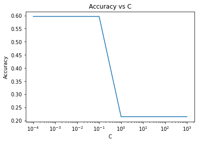

```python
# create an lr_explorer function that finds the best value for C
def lr_explorer(X_train, y_train, X_test, y_test, C_values, solver):
    # create a list to store the accuracy scores
    accuracy = []
    # loop through the C values
    for C in C_values:
        # create a new logistic regression model
        lr = MultiClassLogisticRegression(eta=1,
                                          iterations=10,
                                          C=C,
                                          solver=solver
                                         )
        # fit the model
        lr.fit(X_train, y_train)
        # predict the test set
        yhat = lr.predict(X_test)
        # calculate the accuracy
        accuracy.append(accuracy_score(y_test,yhat))
    # return the accuracy scores
    return accuracy

# create a list of C values to test
C_values = [0.0001, 0.001, 0.01, 0.1, 1, 10, 100, 1000]

# create a list of the accuracy scores for each C value
accuracy_binary = lr_explorer(X_train, y_train, X_test, y_test, C_values, BinaryLogisticRegression)

# plot the accuracy scores against the C values
plt.plot(C_values, accuracy_binary)
plt.xscale('log')
plt.xlabel('C')
plt.ylabel('Accuracy')
plt.title('Accuracy vs C')
plt.show()
```

We then decided to test these same C values in the multiclass logistic regression model utilizing Newton's method.

[figure not shown]

```python
# now show a boxplot of the data across c
from matplotlib import pyplot as plt
%matplotlib inline

# create a list of the accuracy scores for each C value
accuracy = lr_explorer(X_train, y_train, X_test, y_test, C_values, HessianBinaryLogisticRegression)
```

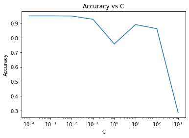

```python
# plot the accuracy scores against the C values
plt.plot(C_values, accuracy)
plt.xscale('log')
plt.xlabel('C')
plt.ylabel('Accuracy')
plt.title('Accuracy vs C')
plt.show()
```

As seen in the resulting plot, we noticed that for this method, the best C_value would be between 0.01 and 0.0001, with a slight decline when passing zero, and then a sharp plummet when approaching 1000.

### Testing the different parameters with various optimization methods

```python
#test several different eta values on the binary logistic regression
eta_values = [0.0001, 0.001, 0.01, 0.1, 1, 10, 100, 1000]

print("Binary Logistic Regression")
for i in eta_values:
    br = MultiClassLogisticRegression(eta=i,
                                  iterations=50,
                                  C=0.001,
                                  solver=BinaryLogisticRegression)
    br.fit(X_train, y_train)
    # print(br)

    yhat = br.predict(X_test)
    print('Accuracy of: ',accuracy_score(y_test,yhat))

print("Line Search Logistic Regression")
for i in eta_values:
    br = MultiClassLogisticRegression(eta=i,
                                  iterations=50,
                                  C=0.001,
                                  solver=LineSearchLogisticRegression)
    br.fit(X_train, y_train)
    # print(br)

    yhat = br.predict(X_test)
    print('Accuracy of: ',accuracy_score(y_test,yhat))

print("Stochastic Gradient Descent")
for i in eta_values:
    br = MultiClassLogisticRegression(eta=i,
                                  iterations=50,
                                  C=0.001,
                                  solver=StochasticLogisticRegression)
    br.fit(X_train, y_train)
    # print(br)

    yhat = br.predict(X_test)
    print('Accuracy of: ',accuracy_score(y_test,yhat))
```

```
Binary Logistic Regression
Accuracy of:  0.5932
Accuracy of:  0.5932
Accuracy of:  0.5932
Accuracy of:  0.5932
Accuracy of:  0.21485
Accuracy of:  0.4619
Accuracy of:  0.58085
Accuracy of:  0.5932
Line Search Logistic Regression
Accuracy of:  0.5932
Accuracy of:  0.5932
Accuracy of:  0.5932
Accuracy of:  0.21485
Accuracy of:  0.5932
Accuracy of:  0.5809
Accuracy of:  0.5932
Accuracy of:  0.5932
Stochastic Gradient Descent
Accuracy of:  0.5932
Accuracy of:  0.5932
Accuracy of:  0.5932
Accuracy of:  0.5932
Accuracy of:  0.5932
Accuracy of:  0.5932
Accuracy of:  0.5932
Accuracy of:  0.5932
```

```python
#test several different eta values on the binary logistic regression
iter_values = [10, 100, 200, 500, 750, 1000]

print("Binary Logistic Regression")
for i in iter_values:
    br = MultiClassLogisticRegression(eta=0.1,
                                  iterations=i,
                                  C=0.001,
                                  solver=BinaryLogisticRegression)
    br.fit(X_train, y_train)
    # print(br)

    yhat = br.predict(X_test)
    print('Accuracy of: ',accuracy_score(y_test,yhat))

print("Stochastic Gradient Descent")
for i in iter_values:
    br = MultiClassLogisticRegression(eta=0.1,
                                  iterations=i,
                                  C=0.001,
                                  solver=StochasticLogisticRegression)
    br.fit(X_train, y_train)
    # print(br)

    yhat = br.predict(X_test)
    print('Accuracy of: ',accuracy_score(y_test,yhat))
```

```
Binary Logistic Regression
Accuracy of:  0.5932
Accuracy of:  0.5932
Accuracy of:  0.5932
Accuracy of:  0.5996
Accuracy of:  0.51255
Accuracy of:  0.3538
Stochastic Gradient Descent
Accuracy of:  0.19195
Accuracy of:  0.5932
Accuracy of:  0.5932
Accuracy of:  0.5932
Accuracy of:  0.5932
Accuracy of:  0.53705
```

### Results of our best algorithm

For our results, we found that the best algorithm for our dataset was Newton's Method, based solely on accuracy. In order to illustrate this accuracy, we decided to calculate a confusion matrix, along with a heatmap.

```
Accuracy of: % 94.825
Number of correct predictions:  18965
Number of correct predictions for each class:  [11388, 4077, 3500]
[[11388   194   282]
 [  220  4077     0]
 [  337     2  3500]]
```

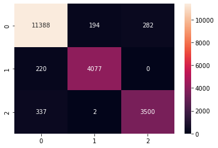

```python
#import the confusion matrix function
from sklearn.metrics import confusion_matrix

#using the accuracy score, calculate a percentage of accuracy
print('Accuracy of: %',accuracy_score(y_test,yhat) * 100)

#print the number of correct predictions out of the total number of predictions
print('Number of correct predictions: ',np.sum(y_test == yhat))

#find the number of correct predictions for each class and store in a list
correct = [np.sum(y_test[y_test == i] == yhat[y_test == i]) for i in range(3)]

#create a list of the number of correct predictions as percentages
percent = [i/len(y_test[y_test == i]) * 100 for i in correct]

#display the number of correct predictions for each class
print('Number of correct predictions for each class: ',correct)

#create a confusion matrix
print(confusion_matrix(y_test,yhat))

#display the confusion matrix as a heatmap
sns.heatmap(confusion_matrix(y_test,yhat),annot=True,fmt='d')
```

## Comparing to Scikit-Learn

Since we decided to use Newton's Method as our best algorithm, we decided to compare our results to the Scikit-Learn version of Newton's Method as well.

```python
#import the sklearn logistic regression
from sklearn.linear_model import LogisticRegression as SKLogisticRegression
```

```python
#call the scikit learn version of newton's method
lr_sk = SKLogisticRegression(solver='newton-cg') # all params default

lr_sk.fit(X_train,y_train)
print(np.hstack((lr_sk.intercept_[:,np.newaxis],lr_sk.coef_)))
yhat = lr_sk.predict(X_test)
print('Accuracy of: ',accuracy_score(y_test,yhat))
```

```
[[ 4.96803546e-02  7.83465031e-06 -3.56352566e-03  1.69427353e-01
   7.58422121e-01 -4.44224652e-01 -4.23680928e-01 -1.35358922e-01
  -3.24663003e-02  2.48094494e-04  1.13137488e+00 -4.70822116e-05
   2.67182626e-05  1.49511233e-05]
 [-4.50253740e-02 -9.20104319e-04 -5.07752399e-03  2.90219254e-01
  -4.46678089e-01  4.91664853e-01 -7.07286593e-02 -1.00344777e-01
   3.50866816e-02 -3.34469536e-04 -4.83788531e+00  9.55445669e-05
  -3.73996920e-05 -2.33631889e-04]
 [-4.65498057e-03  9.12269669e-04  8.64104964e-03 -4.59646607e-01
  -3.11744032e-01 -4.74402010e-02  4.94409587e-01  2.35703699e-01
  -2.62038126e-03  8.63750420e-05  3.70651043e+00 -4.84623550e-05
   1.06814381e-05  2.18680766e-04]]
Accuracy of:  0.89245
```

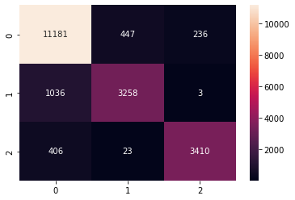

```python
#generate a confusion matrix of the percentage of correct and incorrect predictions
from sklearn.metrics import confusion_matrix
confusion_matrix(y_test, yhat)

#display the confusion matrix as a heatmap
sns.heatmap(confusion_matrix(y_test,yhat),annot=True,fmt='d')
```

## BFGS Implementation (7000 section)

```python
%%time
# for this, we won't perform our own BFGS implementation
# (it takes a fair amount of code and understanding, which we haven't setup yet)
# luckily for us, scipy has its own BFGS implementation:
from scipy.optimize import fmin_bfgs # maybe the most common bfgs algorithm in the world
from numpy import ma
class BFGSBinaryLogisticRegression(BinaryLogisticRegression):

    @staticmethod
    def objective_function(w,X,y,C):
        g = expit(X @ w)
        # invert this because scipy minimizes, but we derived all formulas for maximzing
        return -np.sum(ma.log(g[y==1]))-np.sum(ma.log(1-g[y==0])) + C*sum(w**2)
        #-np.sum(y*np.log(g)+(1-y)*np.log(1-g))

    @staticmethod
    def objective_gradient(w,X,y,C):
        g = expit(X @ w)
        ydiff = y-g # get y difference
        gradient = np.mean(X * ydiff[:,np.newaxis], axis=0)
        gradient = gradient.reshape(w.shape)
        gradient[1:] += -2 * w[1:] * C
        return -gradient

    # just overwrite fit function
    def fit(self, X, y):
        Xb = self._add_bias(X) # add bias term
        num_samples, num_features = Xb.shape

        self.w_ = fmin_bfgs(self.objective_function, # what to optimize
                            np.zeros((num_features,1)), # starting point
                            fprime=self.objective_gradient, # gradient function
                            args=(Xb,y,self.C), # extra args for gradient and objective function
                            gtol=1e-03, # stopping criteria for gradient, |v_k|
                            maxiter=self.iters, # stopping criteria iterations
                            disp=False)

        self.w_ = self.w_.reshape((num_features,1))

bfgslr = BFGSBinaryLogisticRegression(_,iterations=2,C=0.001) # note that we need only a few iterations here

bfgslr.fit(X,y)
yhat = bfgslr.predict(X)
print('Accuracy of: ',accuracy_score(y,yhat))
```

```
Accuracy of:  0.5944559445594456
CPU times: user 3.3 s, sys: 3.9 s, total: 7.21 s
Wall time: 2.44 s
```

This implementation of BFGS pulls from the github, however still requires Scipy and Numpy to run. This also did not yield better results than our Newton, therefor, we would still run with Newton's Method despite the speed increase.